# Lab 2 & 3 Key

```r
needs(tidyverse, rio, here, knitr, kableExtra, misty, janitor, rstatix, psych)

df_2 <- misty::read.sav(here("assignments_data/Lab3_Vocab.sav"),
                      use.value.labels = TRUE) %>%
              clean_names() # cleaning up variable names
```

# 1. Lab 2

## 1.1. Study Description

Our study variables include *Vocabulary Score* as the *Dependent Variable* (DV), a continuous interval scale with scores ranging from 0 to 60 (*M* = 33.5, *SD* = 12.87), and *Lecture Type* as the *Independent Variable* (IV), with three levels of instruction, physical science (coded as 1), social science (coded as 2), and history (coded as 3).

## 1.2. Evaluating ANOVA Assumptions

This is a between-subjects analysis, as students were randomly assigned to only one type of instruction which, along with the balanced sample among groups, supports the *assumption of independence of observations*. The *assumption of normality* seems tenable after visually inspecting the distribution and descriptive statistics for *Vocabulary Scores*. Finally, the *assumption of homogeneity of variance* was not met as Levene’s Test for Homogeneity of Variance was significant (*F*(2, 33)= 7.5, *p* = .002), indicating that the error (within-group) variance around the mean is not equal across groups.

## 1.3. Oneway ANOVA

According to the omnibus *F* statistic for the tested model, there was a significant effect of instruction type on students’ vocabulary scores (*F*(2, 33)= 4.28, *p* = .022), indicating that differences between instruction type accounted for about 21% of the variance among vocabulary scores ($\eta^{2}$ = .206).

### 1.3.a Post-Hoc pariwise comparison

As our data do not meet the assumption of *homogeneity of variances*, I used the Games‐Howell post-hoc test to adjust for multiple tests, comparing each pair of means across the three instruction groups. The results indicate that the mean scores for students in the physical science group are significant differently from their peers in the social science group (*$p_{adj}$* = .043).

```r
describe(df_2) %>%
  select(n, mean, sd, skew, kurtosis, se)
```

```
##            n mean    sd  skew kurtosis   se
## idnum     36 18.5 10.54  0.00    -1.30 1.76
## vocab     36 33.5 12.87 -0.54    -0.87 2.14
## instruct* 36  2.0  0.83  0.00    -1.58 0.14
```

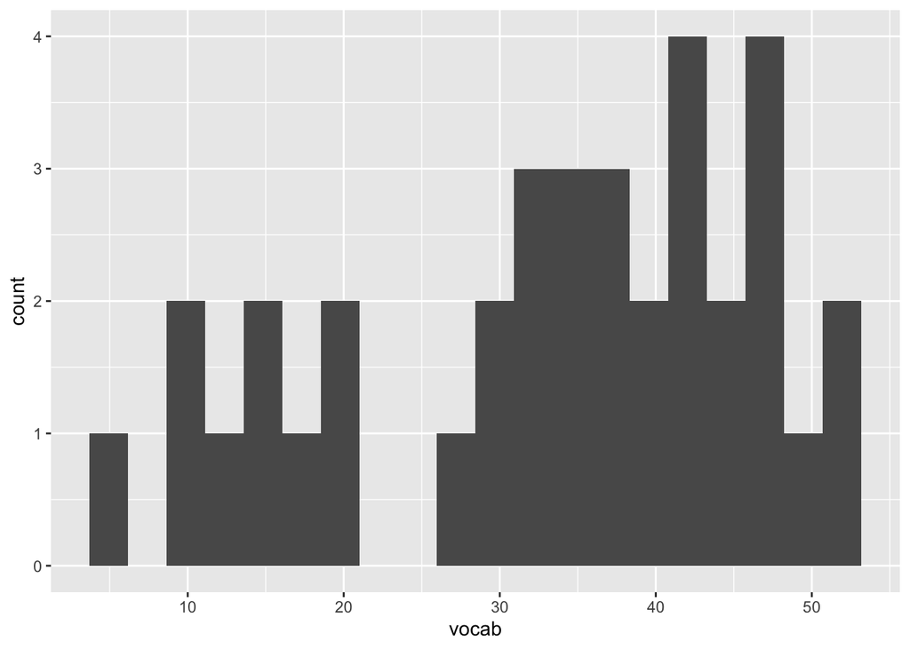

```r
# Histogram
ggplot(data = df_2, aes(x = vocab)) +
  geom_histogram(bins = 20)
```

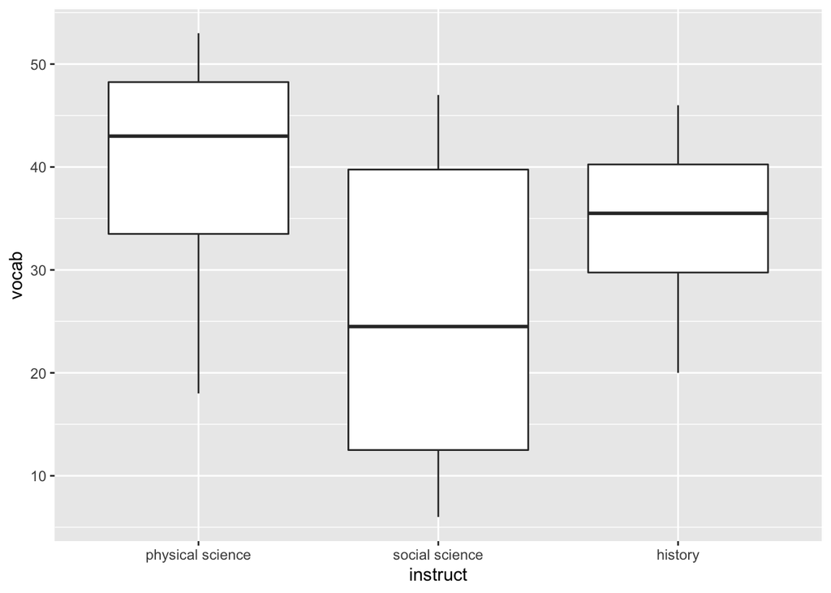

```r
# Boxplot
ggplot(data = df_2, aes(x = instruct, y = vocab)) +
  geom_boxplot()
```

```r
# Homogeneity of variance
needs(car)
car::leveneTest(vocab ~ instruct, data = df_2, center = "mean")
```

```
## Levene's Test for Homogeneity of Variance (center = "mean")
##       Df F value   Pr(>F)
## group  2  7.5054 0.002058 **
##       33
## ---
## Signif. codes:  0 '***' 0.001 '**' 0.01 '*' 0.05 '.' 0.1 ' ' 1
```

```r
needs(afex)
aov_car(vocab ~ instruct + Error(idnum), data = df_2)
```

```
## Contrasts set to contr.sum for the following variables: instruct
```

```
## Anova Table (Type 3 tests)
##
## Response: vocab
##     Effect    df    MSE      F  ges p.value
## 1 instruct 2, 33 139.36 4.28 * .206    .022
## ---
## Signif. codes:  0 '***' 0.001 '**' 0.01 '*' 0.05 '+' 0.1 ' ' 1
```

```r
#Games-Howell (used if assumption of variance homogeneity is violated)
games_howell_test(df_2, vocab ~ instruct,
                  conf.level = 0.95,
                  detailed = FALSE)
```

```
## # A tibble: 3 × 8
##   .y.   group1           group2   estimate conf.low conf.high p.adj p.adj.signif
## * <chr> <chr>            <chr>       <dbl>    <dbl>     <dbl> <dbl> <chr>
## 1 vocab physical science social …    -14     -27.6     -0.374 0.043 *
## 2 vocab physical science history      -5.5   -15.5      4.46  0.363 ns
## 3 vocab social science   history       8.5    -4.35    21.4   0.235 ns
```

```r
# Calculating Omega Square
needs(MOTE)
omega.F(dfm = 2, dfe = 33,
      Fvalue = 4.284, n = 36, a = .05)
```

```
## $omega
## [1] 0.1542943
##
## $omegalow
## [1] 0
##
## $omegahigh
## [1] 0.3783572
##
## $dfm
## [1] 2
##
## $dfe
## [1] 33
##
## $F
## [1] 4.284
##
## $p
## [1] 0.02217963
##
## $estimate
## [1] "$\\omega^2$ = 0.15, 95\\% CI [0.00, 0.38]"
##
## $statistic
## [1] "$F$(2, 33) = 4.28, $p$ = .022"
```

# 2. Lab 3

## 2.1. *“a priori”* contrasts

For *a priori* tests (a bad practice because I have already examined these data, but I need the practice with creating orthogonal contrasts, so we’ll let it slide for this exercise), I created two contrasts to test a couple of hypotheses:  
**$H_{1}$.** The mean vocabulary score for students in the social science group is significantly different from the other types of instruction.  
**$H_{2}$.** The mean vocabulary score for students in the physical science group is significantly different from the history group.

Results support my first hypothesis, that the average vocabulary score for social science is significantly different from the other types of instruction (*t* = -2.69, *p* = .011). Results for my second hypothesis were not supported, where the difference between average vocabulary score in the physical science group was not significantly different from the history group (*t* = 1.14, *p* = .26).

```r
# Check the order of levels
levels(df_2$instruct)
```

```
## [1] "physical science" "social science"   "history"
```

```r
#### 2.2. Creating a priori contrasts ####

# Step 1. Set Helmert contrasts
contrast1 <- c(-.5, 1, -.5) #social science vs others
contrast2 <- c(1, 0, -1) #physical science vs history

# Step 2. Bind vectors to temporary matrix, where constants are equal to 1/(length of vectors)
mat.temp <- rbind(constant = 1/3, contrast1, contrast2) #3 is for number of cells in the design (same as levels because only one IV)

# Step 3. Take the inverse of the matrix.
mat <- solve(mat.temp)
# drop first column in the matrix, the one with the constants (i.e., = 1)
mat <- mat[, -1]

# Step 4. Run model with lm() and include 'contrast = list(instruct = mat)' to indicate that the function should use the 'mat' matrix as the contrast coefficients for the 'instruct' variable
m_contrasts <- lm(vocab ~ instruct, data = df_2, contrasts = list(instruct = mat))
summary(m_contrasts)
```

```
##
## Call:
## lm(formula = vocab ~ instruct, data = df_2, contrasts = list(instruct = mat))
##
## Residuals:
##     Min      1Q  Median      3Q     Max
## -22.000 -10.000   1.750   9.375  21.000
##
## Coefficients:
##                   Estimate Std. Error t value Pr(>|t|)
## (Intercept)         33.500      1.968  17.026   <2e-16 ***
## instructcontrast1  -11.250      4.174  -2.695    0.011 *
## instructcontrast2    5.500      4.819   1.141    0.262
## ---
## Signif. codes:  0 '***' 0.001 '**' 0.01 '*' 0.05 '.' 0.1 ' ' 1
##
## Residual standard error: 11.81 on 33 degrees of freedom
## Multiple R-squared:  0.2061, Adjusted R-squared:  0.158
## F-statistic: 4.284 on 2 and 33 DF,  p-value: 0.02218
```

## 2.2. *post hoc* contrasts

Prior to examining my *post hoc* hypotheses, I calculated an adjusted ${\alpha}$ threshold for significance to account for the Type I error rate arising from multiple comparisons I have conducted using these data (${\alpha}$ = .05/5 = .01). Thus my new threshold for a significant *p*-value is *p* < .01.

Regarding the variance accounted for by the tested models, it appears that there may be some bias reflected in $\eta^{2}$ (.206) compared to the $\omega^{2}$ effect size statistic ($\omega^{2}$ = .154), reflecting a 6% difference in variance explained by the model between the two effect sizes. Therefore, $\omega^{2}$ is likely a more accurate estimate of the magnitude of the effect.

```r
#### 2.2. Creating post hoc contrasts ####
# Step 1. Set Helmert contrasts
contrast1 <- c(1, -.5, -.5) #physical science vs others
contrast2 <- c(0, 1, -1) #social science vs history

# Step 2. Bind vectors to temporary matrix, where constants are equal to 1/(length of vectors)
mat.temp <- rbind(constant = 1/3, contrast1, contrast2) #3 is for number of cells in the design (same as levels because only one IV)

# Step 3. Take the inverse of the matrix.
mat <- solve(mat.temp)
# drop first column in the matrix, the one with the constants (i.e., = 1)
mat <- mat[, -1]

# Step 4. Run model with lm() and include 'contrast = list(instruct = mat)' to indicate that the function should use the 'mat' matrix as the contrast coefficients for the 'instruct' variable
m_contrasts <- lm(vocab ~ instruct, data = df_2, contrasts = list(instruct = mat))
summary(m_contrasts)
```

```
##
## Call:
## lm(formula = vocab ~ instruct, data = df_2, contrasts = list(instruct = mat))
##
## Residuals:
##     Min      1Q  Median      3Q     Max
## -22.000 -10.000   1.750   9.375  21.000
##
## Coefficients:
##                   Estimate Std. Error t value Pr(>|t|)
## (Intercept)         33.500      1.968  17.026   <2e-16 ***
## instructcontrast1    9.750      4.174   2.336   0.0257 *
## instructcontrast2   -8.500      4.819  -1.764   0.0870 .
## ---
## Signif. codes:  0 '***' 0.001 '**' 0.01 '*' 0.05 '.' 0.1 ' ' 1
##
## Residual standard error: 11.81 on 33 degrees of freedom
## Multiple R-squared:  0.2061, Adjusted R-squared:  0.158
## F-statistic: 4.284 on 2 and 33 DF,  p-value: 0.02218
```

```r
# Obtaining generalized eta squared
anova_test(m_contrasts,
                 type="III",
                 effect.size = "ges",
                 detailed = TRUE)
```

```
## Coefficient covariances computed by hccm()
```

```
## ANOVA Table (type tests)
##
##        Effect   SSn  SSd DFn DFd       F        p p<.05   ges
## 1 (Intercept) 40401 4599   1  33 289.896 6.57e-18     * 0.898
## 2    instruct  1194 4599   2  33   4.284 2.20e-02     * 0.206
```

```r
# Calculating Omega Square
needs(MOTE)
omega.F(dfm = 2, dfe = 33,
      Fvalue = 4.284, n = 36, a = .01)
```

```
## $omega
## [1] 0.1542943
##
## $omegalow
## [1] 0
##
## $omegahigh
## [1] 0.4604493
##
## $dfm
## [1] 2
##
## $dfe
## [1] 33
##
## $F
## [1] 4.284
##
## $p
## [1] 0.02217963
##
## $estimate
## [1] "$\\omega^2$ = 0.15, 99\\% CI [0.00, 0.46]"
##
## $statistic
## [1] "$F$(2, 33) = 4.28, $p$ = .022"
```